# Is Cycle Threshold A Worthwhile Clinical Metric for SARS-CoV2?

Andrew D. Johnston

08/31/2020

Goals of Analysis

1. Calculate the Ct value difference between Expired and Survivors for each Machine - Cepheid, Hologic, and Abbott
2. Calculate the Youden index for each Machine - Cepheid, Hologic, and Abbott
3. Examine the variability of samples taken within 48 hours of each other.
4. Observe how many specimen pairs cross the Youden Index for their respective machine

```r
# load in libraries
library(data.table)
library(ggplot2)
library(ggthemes)
library(reshape2)
library(ggpubr)
library(RColorBrewer)
library(MASS)
library(AER)
library(scales)
library(Hmisc)
library("flexplot")
library(overlapping)
library(lattice)
library(lubridate)
library(ROCit)
library(pROC)
library(plotROC)
library(OptimalCutpoints)
library(cutpointr)
library(pastecs)

# set options
options(scipen=999, stringsAsFactors = FALSE)
```

Loading in the mortatlity data for each COVID specimen

```r
mort_dat <- fread("Data_used/COVID_POS_SURVIVAL_short.csv",  header = T)
mort_dat <- as.data.frame(mort_dat)
dim(mort_dat)
```

```
## [1] 9646    5
```

```r
mort_dat$Alive <- "Survivor"
mort_dat$Alive[mort_dat$`Patient Age`=="Deceased"] <- "Expired"
mort_dat$Alive <- factor(mort_dat$Alive, levels = c("Survivor", "Expired"))
```

1a) Obtaining the CT differences between expired and survivor for Cephied Machine

```r
cephied_dat <- fread("Data_used/sarsCoV2-cepheid_ct.csv", header = T)
cephied_dat <- as.data.frame(cephied_dat)
cephied_dat <- cephied_dat[1:11490,] # R read in all the empty rows
cephied_dat <- cephied_dat[,-c(4,6,8)] # R read in all the empty rows
colnames(cephied_dat) <- c("MRN", "Spec_ID", "Result", "Ct_E", "Ct_n", "Ct_Control","start_time")
head(cephied_dat)
```

```
##       MRN      Spec_ID              Result Ct_E Ct_n Ct_Control start_time
## 1 2993898 MMI095200365               ERROR 18.6 21.0       28.0     4/4/20
## 2 2499295 MMI095200364 SARS-CoV-2 POSITIVE 24.2 26.4       27.9     4/4/20
## 3  461922 MMI095200439 SARS-CoV-2 POSITIVE 33.1 35.9       28.2     4/4/20
## 4 3739192 MMI095200493 SARS-CoV-2 NEGATIVE  0.0  0.0       27.9     4/4/20
## 5 3449638 MMI095200492               ERROR  0.0  0.0        0.0     4/4/20
## 6 5644169 MMI095200512 SARS-CoV-2 NEGATIVE  0.0  0.0       28.3     4/4/20
```

```r
dim(cephied_dat)
```

```
## [1] 11490     7
```

```r
# any with same spec ID - QC
any(duplicated(cephied_dat$Spec_ID))
```

```
## [1] TRUE
```

```r
# clear all negative and error and
filter_cepheid <-c("NEGATIVE","ERROR","INVALID", "NO RESULT")
idx_cephied_filter <- grep(paste0(filter_cepheid, collapse = "|"), x = cephied_dat$Result, value = FALSE)
length(idx_cephied_filter) #9589
```

```
## [1] 9589
```

```r
cephied_dat <- cephied_dat[-idx_cephied_filter,]
table(cephied_dat$Result)
```

```
##
##        SARS-CoV-2 POSITIVE SARS-CoV-2 PRESUMPTIVE POS
##                       1828                         73
```

```r
# there are 11 samples in which the control probe did not result but they were deemed positive anyways, so I'll keep them
cephied_dat[which(cephied_dat$Ct_Control==0),]
```

```
##           MRN      Spec_ID              Result Ct_E Ct_n Ct_Control start_time
## 6468  3490512 MMI172200284 SARS-CoV-2 POSITIVE 18.6 20.5          0    6/20/20
## 7362  6674505 MVL185200004 SARS-CoV-2 POSITIVE 18.5 20.2          0     7/3/20
## 8497  2399267 MMI200200023 SARS-CoV-2 POSITIVE 15.2 18.2          0    7/18/20
## 9944  2725953 MMI218200224 SARS-CoV-2 POSITIVE 19.4 21.0          0     8/5/20
## 10356 2399267 MMI223200259 SARS-CoV-2 POSITIVE 14.3 16.9          0    8/10/20
## 10878 3810517 MMI229200589 SARS-CoV-2 POSITIVE 19.0 20.8          0    8/17/20
## 10902 5810081 MMI230200123 SARS-CoV-2 POSITIVE 15.2 17.2          0    8/17/20
## 10933 6622603 MMI230200736 SARS-CoV-2 POSITIVE 16.2 18.4          0    8/17/20
## 10996 2941208 MMI231200768 SARS-CoV-2 POSITIVE 17.3 19.4          0    8/18/20
## 11023 5869564 MVL231201645 SARS-CoV-2 POSITIVE 15.8 17.3          0    8/18/20
## 11486 2800481 MMI237200844 SARS-CoV-2 POSITIVE 14.8 17.3          0    8/24/20
```

```r
# head(cephied_dat[cephied_dat$Result=="SARS-CoV-2 PRESUMPTIVE POS",],50)
# head(cephied_dat[which(cephied_dat$Ct_E==0),])
# the presumptive positives were when E probe was positive but N probe was undetected
# removing Ct_N value of 0
cephied_dat <- cephied_dat[-which(cephied_dat$Ct_n==0),]
dim(cephied_dat) # 1828
```

```
## [1] 1828    7
```

```r
cephied_dat_mort <- merge(x=cephied_dat, y=mort_dat, by.x = "Spec_ID", by.y = "Specimen ID")
dim(cephied_dat_mort) # lost two in the merge; 1826
```

```
## [1] 1826   12
```

```r
wilcox.test(cephied_dat_mort$Ct_n[cephied_dat_mort$Alive=="Survivor"],cephied_dat_mort$Ct_n[cephied_dat_mort$Alive=="Expired"], conf.int=TRUE)
```

```
##
##  Wilcoxon rank sum test with continuity correction
##
## data:  cephied_dat_mort$Ct_n[cephied_dat_mort$Alive == "Survivor"] and cephied_dat_mort$Ct_n[cephied_dat_mort$Alive == "Expired"]
## W = 341890, p-value < 0.00000000000000022
## alternative hypothesis: true location shift is not equal to 0
## 95 percent confidence interval:
##  4.300053 6.299982
## sample estimates:
## difference in location
##               5.299954
```

```r
# 95 percent confidence interval:
# 4.300053 6.299982
# difference in location
#              5.299954

median(cephied_dat_mort$Ct_n[cephied_dat_mort$Alive=="Survivor"])-median(cephied_dat_mort$Ct_n[cephied_dat_mort$Alive=="Expired"])
```

```
## [1] 6.8
```

```r
mean(cephied_dat_mort$Ct_n[cephied_dat_mort$Alive=="Survivor"])-mean(cephied_dat_mort$Ct_n[cephied_dat_mort$Alive=="Expired"])
```

```
## [1] 4.938142
```

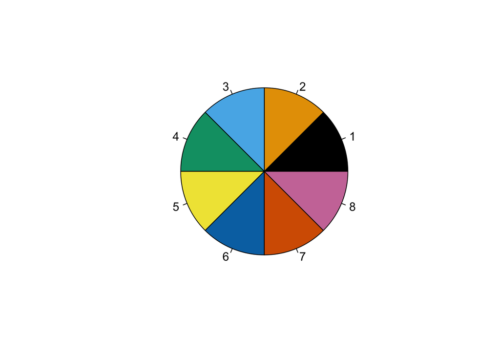

```r
colorBlindBlack8  <- c("#000000", "#E69F00", "#56B4E9", "#009E73",
                       "#F0E442", "#0072B2", "#D55E00", "#CC79A7")
pie(rep(1, 8), col = colorBlindBlack8)
```

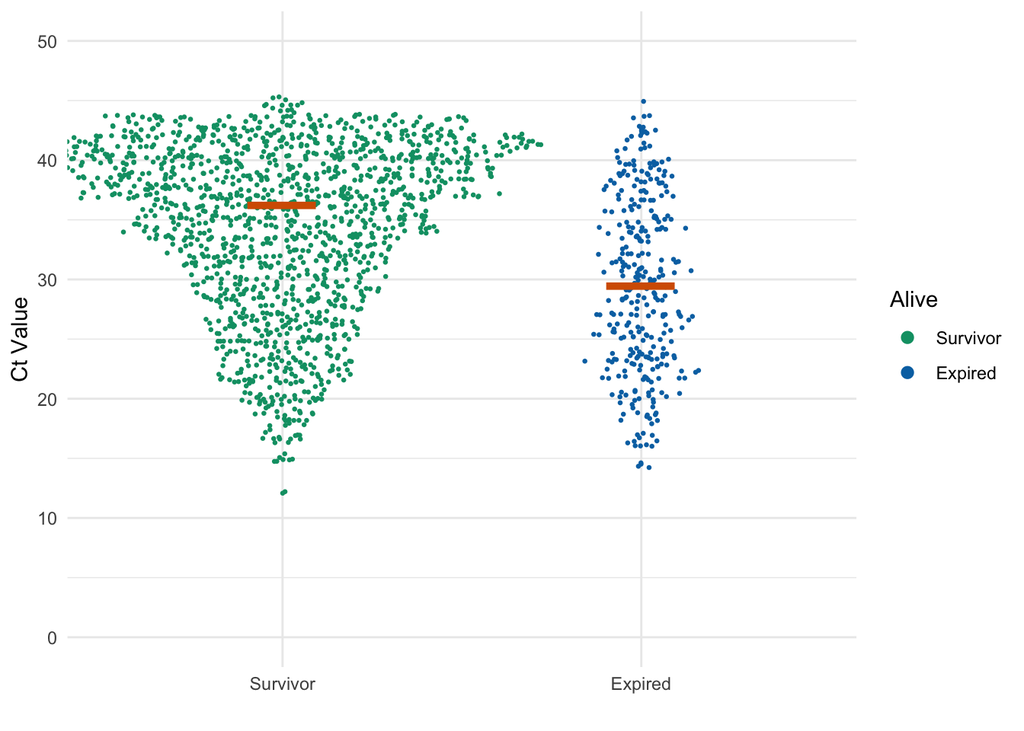

```r
dark_col <- brewer.pal(6,"Dark2")
fig_ct_method_cephied <- ggplot(cephied_dat_mort, aes(x=Alive, y=Ct_n, fill=Alive)) +
geom_dotplot(binaxis='y', stackdir='center', stackratio=.5, dotsize=.25, col=NA, position = position_jitterd(width = .05, height = 1, quad.points = 1, seed = 7)) +
  theme_minimal() +
  scale_fill_manual(values=colorBlindBlack8[c(4,6)]) +
  stat_summary(data = cephied_dat_mort, mapping = aes(x=as.numeric(as.factor((Alive))), y=Ct_n), fun.y= "median", geom="point", color=colorBlindBlack8[7], inherit.aes = FALSE, shape = 95, size=20) +
  xlab("")+
  ylab("Ct Value") +
  ylim(c(0,50))
fig_ct_method_cephied
```

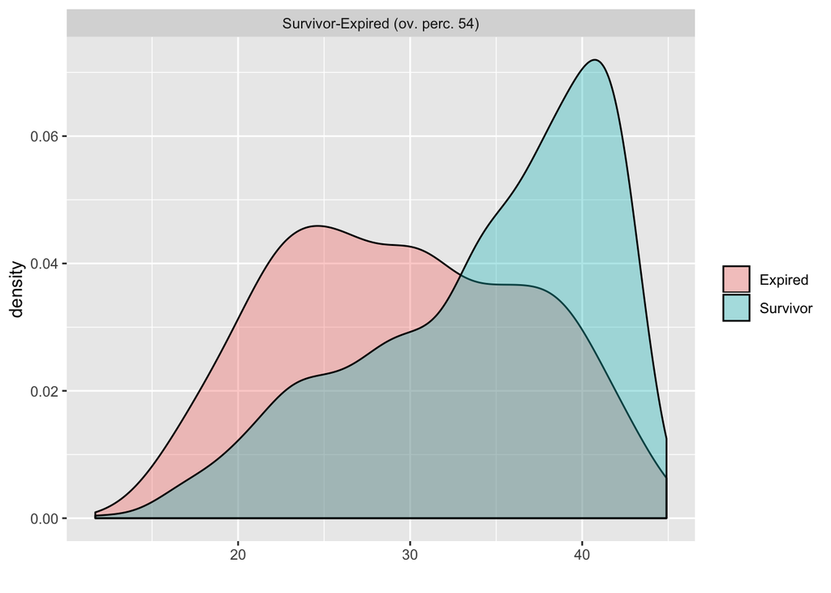

```r
#ggsave(plot = fig_ct_method_cephied, filename = "Fig1_cephied.pdf", width=4.5, height=3, useDingbats=FALSE)

# plot AUC overlap between survivor and expired
AUC_overlap_cephied <- list(Survivor=cephied_dat_mort$Ct_n[cephied_dat_mort$Alive=="Survivor"], Expired=cephied_dat_mort$Ct_n[cephied_dat_mort$Alive=="Expired"])
AUC_overlap_plot_cephied <- overlap(AUC_overlap_cephied, plot=TRUE, theme = theme_minimal)
```

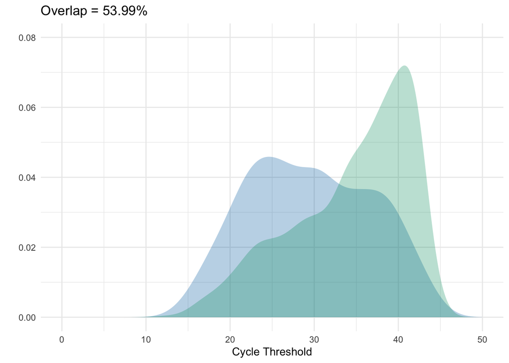

```r
fig_ct_overlap_cephied <- ggplot(AUC_overlap_plot_cephied$DD, aes(x,y1)) +
  geom_ribbon(aes(ymin=0,ymax=y2),alpha=.3,fill=colorBlindBlack8[c(6)])+
  geom_ribbon(aes(ymin=0,ymax=y1),alpha=.3,fill=colorBlindBlack8[c(4)])+
  xlab("Cycle Threshold")+
  xlim(c(0,50)) +
  ylab("") +
  theme_minimal()+
  ylim(c(0,0.08))+
  ggtitle(paste0("Overlap = ",round(AUC_overlap_plot_cephied$OV*100,2),"%"))
fig_ct_overlap_cephied
```

```r
#ggsave(plot = fig_ct_overlap_cephied, filename = "Fig1_overlap_cephied.pdf", width=2.5, height=2.5, useDingbats=FALSE)
```

2a) Obtaining the Youden Index for the Cephied machine

```r
rocfit_cepheid <- pROC::roc(cephied_dat_mort$Alive, cephied_dat_mort$Ct_n)
pROC::auc(rocfit_cepheid)
```

```
## Area under the curve: 0.6925
```

```r
youden_coord_cephied<- pROC::coords(rocfit_cepheid, x = "b")
summary(cephied_dat_mort$Ct_n)
```

```
##    Min. 1st Qu.  Median    Mean 3rd Qu.    Max.
##   11.70   28.10   35.10   33.55   39.70   44.90
```

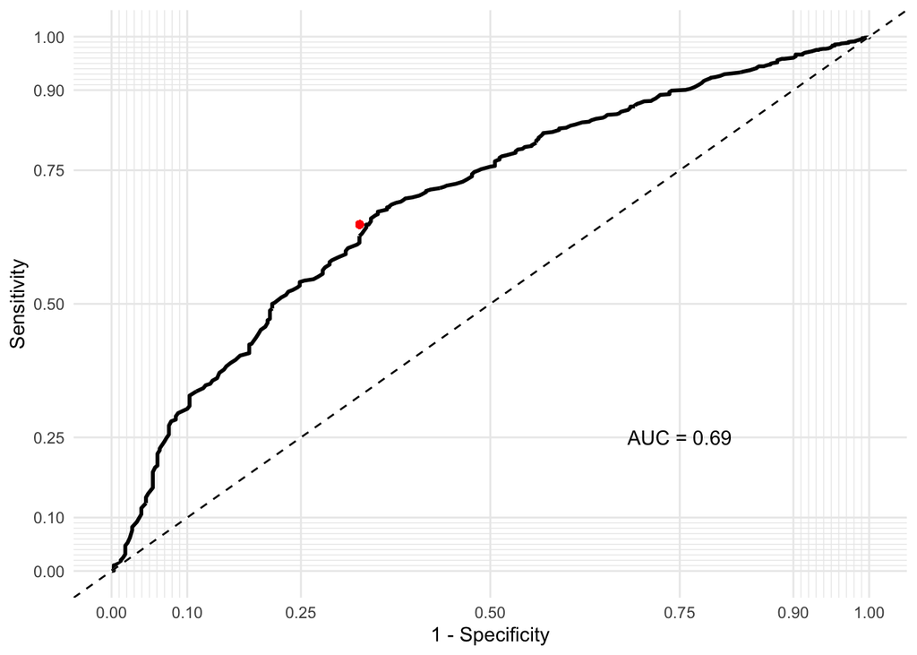

```r
rocplot_cepheid <- ggplot(cephied_dat_mort, aes(m = Ct_n, d = Alive)) +
  geom_roc(n.cuts=0)
rocplot_cepheid <- rocplot_cepheid + style_roc(theme = theme_minimal, xlab = "1 - Specificity", ylab = "Sensitivity") +
  annotate("text", x = .75, y = .25,
           label = paste("AUC =", round(calc_auc(rocplot_cepheid)$AUC, 2)))  +
  geom_point(aes(x=1-youden_coord_cephied$specificity, y=youden_coord_cephied$sensitivity), colour="red")+
  geom_abline(slope=1, intercept=0, lty="dashed")
  #ggtitle("Cepheid ROC")
rocplot_cepheid
```

```r
#ggsave(plot = rocplot_cepheid, filename = "Fig1_roc_cephied.pdf", width=2.5, height=2.5, useDingbats=FALSE)
```

1b) Obtaining the CT differences between expired and survivor for Hologic Machine

```r
hologic_dat <- fread("Copy of pcrbase.csv", header = T)
hologic_dat <- as.data.frame(hologic_dat)
dim(hologic_dat) #16732
```

```
## [1] 16732     9
```

```r
#sanity check- duplicated specimen IDs?
any(duplicated(hologic_dat$Spec_name))
```

```
## [1] TRUE
```

```r
sum(duplicated(hologic_dat$Spec_name)) #412
```

```
## [1] 412
```

```r
#removing duplicates
hologic_dat <- hologic_dat[!duplicated(hologic_dat$Spec_name),]

# sort based on MRN then time collected
hologic_dat <- hologic_dat[order(hologic_dat$mrn),]

# making MRN numeric
hologic_dat$mrn <- as.numeric(hologic_dat$mrn)

# remove the hologi as well as NA MRN patients
hologic_dat <- hologic_dat[-c(1:2),]
sum(is.na(hologic_dat$mrn)) #130
```

```
## [1] 130
```

```r
hologic_dat <- hologic_dat[!is.na(hologic_dat$mrn),]

#removing negative tests
table(hologic_dat$Result)
```

```
##
##   neg   POS
## 13331  2857
```

```r
hologic_dat <- hologic_dat[hologic_dat$Result=="POS",]

#QC
table(hologic_dat$IC_valid)
```

```
##
## Valid
##  2857
```

```r
summary(hologic_dat$Control_Ct)
```

```
##    Min. 1st Qu.  Median    Mean 3rd Qu.    Max.    NA's
##   29.30   30.70   31.00   31.12   31.40   35.80       4
```

```r
dim(hologic_dat)
```

```
## [1] 2857    9
```

```r
hologic_dat_mort <- merge(x=hologic_dat, y=mort_dat, by.x = "Spec_name", by.y = "Specimen ID")
dim(hologic_dat_mort)
```

```
## [1] 2857   14
```

```r
wilcox.test(hologic_dat_mort$Ct[hologic_dat_mort$Alive=="Survivor"],hologic_dat_mort$Ct[hologic_dat_mort$Alive=="Expired"], conf.int=TRUE)
```

```
##
##  Wilcoxon rank sum test with continuity correction
##
## data:  hologic_dat_mort$Ct[hologic_dat_mort$Alive == "Survivor"] and hologic_dat_mort$Ct[hologic_dat_mort$Alive == "Expired"]
## W = 690220, p-value < 0.00000000000000022
## alternative hypothesis: true location shift is not equal to 0
## 95 percent confidence interval:
##  3.499936 5.000038
## sample estimates:
## difference in location
##               4.299973
```

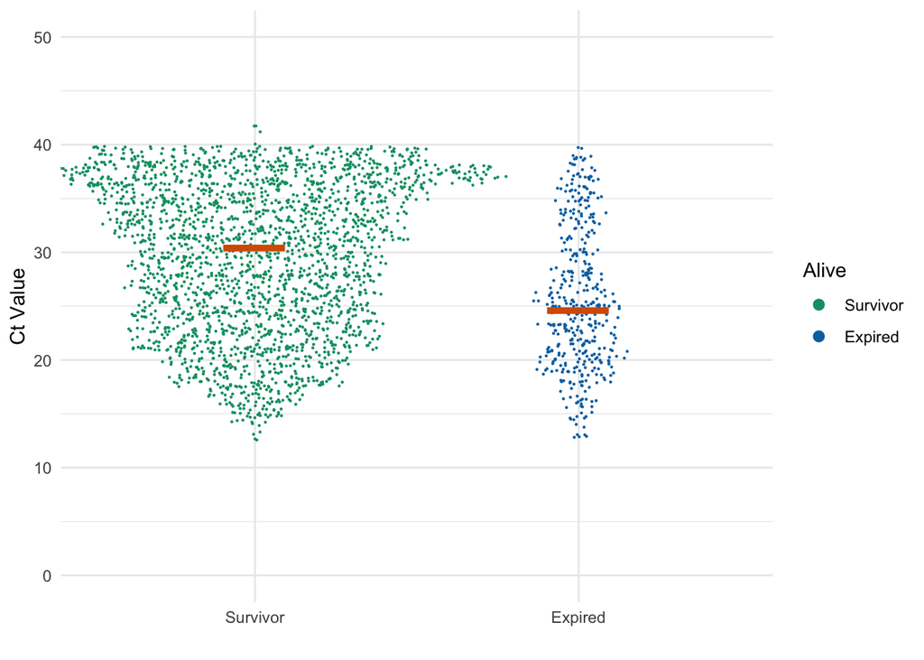

```r
# 95 percent confidence interval:
# 3.499936 5.000038
# sample estimates:
# difference in location
#              4.299973

fig_ct_method_hologic <- ggplot(hologic_dat_mort, aes(x=Alive, y=Ct, fill=Alive)) +
geom_dotplot(binaxis='y', stackdir='center', stackratio=.5, dotsize=.17, col=NA, position = position_jitterd(width = .05, height = 1, quad.points = 1, seed = 7)) +
  theme_minimal() +
  scale_fill_manual(values=colorBlindBlack8[c(4,6)]) +
  stat_summary(data = hologic_dat_mort, mapping = aes(x=as.numeric(as.factor((Alive))), y=Ct), fun.y= "median", geom="point", color=colorBlindBlack8[7], inherit.aes = FALSE, shape = 95, size=20) +
  xlab("")+
  ylab("Ct Value") +
  ylim(c(0,50))
fig_ct_method_hologic
```

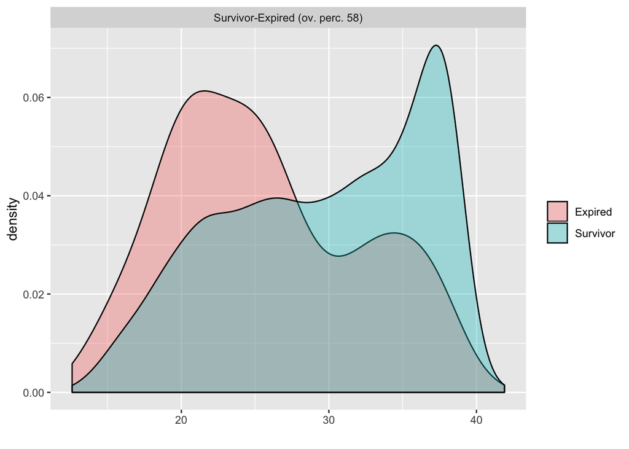

```r
#ggsave(plot = fig_ct_method_hologic, filename = "Fig1_hologic.pdf", width=4.5, height=3, useDingbats=FALSE)

# plot AUC overlap between survivor and expired
AUC_overlap_hologic <- list(Survivor=hologic_dat_mort$Ct[hologic_dat_mort$Alive=="Survivor"], Expired=hologic_dat_mort$Ct[hologic_dat_mort$Alive=="Expired"])
AUC_overlap_plot_hologic <- overlap(AUC_overlap_hologic, plot=TRUE)
```

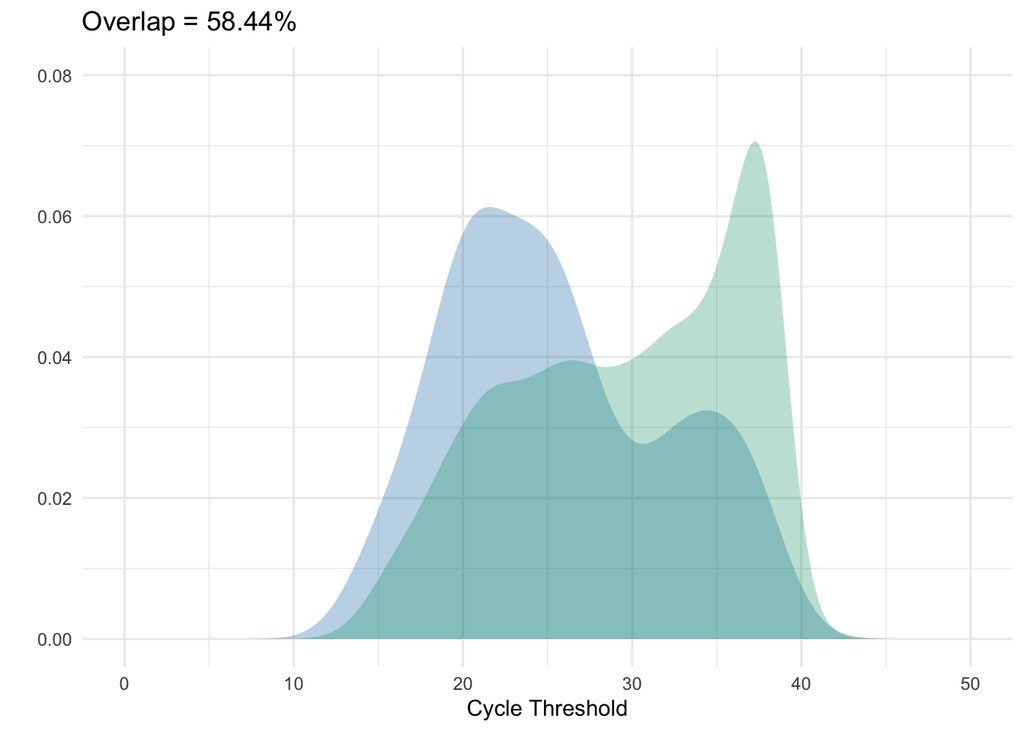

```r
fig_ct_overlap_hologic <- ggplot(AUC_overlap_plot_hologic$DD, aes(x,y1)) +
  geom_ribbon(aes(ymin=0,ymax=y2),alpha=.3,fill=colorBlindBlack8[c(6)])+
  geom_ribbon(aes(ymin=0,ymax=y1),alpha=.3,fill=colorBlindBlack8[c(4)])+
  xlab("Cycle Threshold")+
  xlim(c(0,50)) +
  ylab("") +
  ylim(c(0,0.08))+
  theme_minimal()+
  ggtitle(paste0("Overlap = ",round(AUC_overlap_plot_hologic$OV*100,2),"%"))
fig_ct_overlap_hologic
```

```r
#ggsave(plot = fig_ct_overlap_hologic, filename = "Fig1_overlap_hologic.pdf", width=2.5, height=2.5, useDingbats=FALSE)
```

2b) Obtaining the Youden Index for the Hologic machine

```r
rocfit_hologic <- pROC::roc(as.character(hologic_dat_mort$Alive), hologic_dat_mort$Ct)
pROC::auc(rocfit_hologic)
```

```
## Area under the curve: 0.6678
```

```r
youden_coord_hologic<- pROC::coords(rocfit_hologic, x = "b")
youden_coord_hologic
```

```
##   threshold specificity sensitivity
## 1     28.25   0.6941176   0.5851151
```

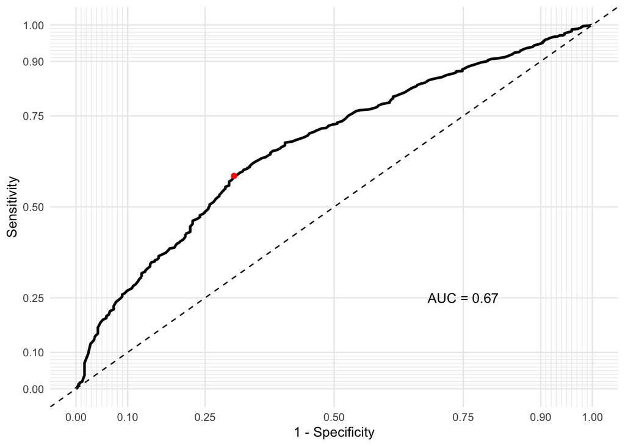

```r
rocplot_hologic<- ggplot(hologic_dat_mort, aes(m = Ct, d = Alive)) +
  geom_roc(n.cuts=0)
rocplot_hologic <- rocplot_hologic + style_roc(theme = theme_minimal, xlab = "1 - Specificity", ylab = "Sensitivity") +
  annotate("text", x = .75, y = .25,
           label = paste("AUC =", round(calc_auc(rocplot_hologic)$AUC, 2)))  +
  geom_point(aes(x=1-youden_coord_hologic$specificity, y=youden_coord_hologic$sensitivity), colour="red")+
  geom_abline(slope=1, intercept=0, lty="dashed")
  #ggtitle("Hologic ROC")
rocplot_hologic
```

```r
#ggsave(plot = rocplot_hologic, filename = "Fig1_roc_hologic.pdf", width=2.5, height=2.5, useDingbats=FALSE)
```

```r
abbott_dat <- fread("Ct_study_race.csv", header = T)
abbott_dat <- as.data.frame(abbott_dat)
dim(abbott_dat)
```

```
## [1] 2038   27
```

```r
# sanity checks
## are there duplicates? No
any(duplicated(abbott_dat$MR)) # FALSE
```

```
## [1] FALSE
```

```r
any(duplicated(abbott_dat$`Specimen ID`)) # FALSE
```

```
## [1] FALSE
```

```r
# how many samples don't have a CT value
sum(is.na(abbott_dat$Ct)) # 2
```

```
## [1] 2
```

```r
#  How many samples have ct of 0?
sum(abbott_dat$Ct==0, na.rm = TRUE) # 1
```

```
## [1] 1
```

```r
# I'm removing these four  samples
abbott_dat <- abbott_dat[!(is.na(abbott_dat$Ct)) & !(abbott_dat$Ct==0),]
dim(abbott_dat)
```

```
## [1] 2035   27
```

```r
# remove unecessary columns (Patient Name, Component, Column 3, method)
colnames(abbott_dat)
```

```
##  [1] "Specimen ID"           "MR"                    "Patient Name"
##  [4] "Component"             "Race"                  "Ethnicity"
##  [7] "Method"                "Method Abbr"           "Value"
## [10] "Resulted"              "Collected"             "Patient Age"
## [13] "Gender"                "DOB"                   "Ordering Provider"
## [16] "Age at Collection"     "Collection Department" "Alive"
## [19] "Specimen Id2"          "Ct"                    "Column1"
## [22] "D-Dimer"               "LDH"                   "WBC"
## [25] "CRP"                   "Creat"                 "Column3"
```

```r
abbott_dat <- abbott_dat[,-c(3:4,7,21:27)]

# only using Abbott data points
abbott_dat <-subset(abbott_dat, `Method Abbr`=="m2000")
dim(abbott_dat)
```

```
## [1] 1190   17
```

```r
# sort based on MRN then time collected
abbott_dat <- abbott_dat[order(abbott_dat$MR),]

# making MRN numeric
abbott_dat$MR <- as.numeric(abbott_dat$MR)
sum(is.na(abbott_dat$mrn))
```

```
## [1] 0
```

```r
table(abbott_dat$Value)
```

```
##
## DETECTED
##     1190
```

```r
summary(abbott_dat$Ct)
```

```
##    Min. 1st Qu.  Median    Mean 3rd Qu.    Max.
##    1.00    8.88   13.58   13.82   18.01   31.04
```

```r
#combining with mortaility data
dim(abbott_dat)
```

```
## [1] 1190   17
```

```r
abbott_dat_mort <- merge(x=abbott_dat, y=mort_dat, by.x = "Specimen ID", by.y = "Specimen ID")
dim(abbott_dat_mort) # all were kept :-)
```

```
## [1] 1190   22
```

```r
colnames(abbott_dat_mort)[22] <- "Alive"

wilcox.test(abbott_dat_mort$Ct[abbott_dat_mort$Alive=="Survivor"],abbott_dat_mort$Ct[abbott_dat_mort$Alive=="Expired"], conf.int=TRUE)
```

```
##
##  Wilcoxon rank sum test with continuity correction
##
## data:  abbott_dat_mort$Ct[abbott_dat_mort$Alive == "Survivor"] and abbott_dat_mort$Ct[abbott_dat_mort$Alive == "Expired"]
## W = 164050, p-value = 0.000006747
## alternative hypothesis: true location shift is not equal to 0
## 95 percent confidence interval:
##  1.059992 2.669944
## sample estimates:
## difference in location
##               1.859981
```

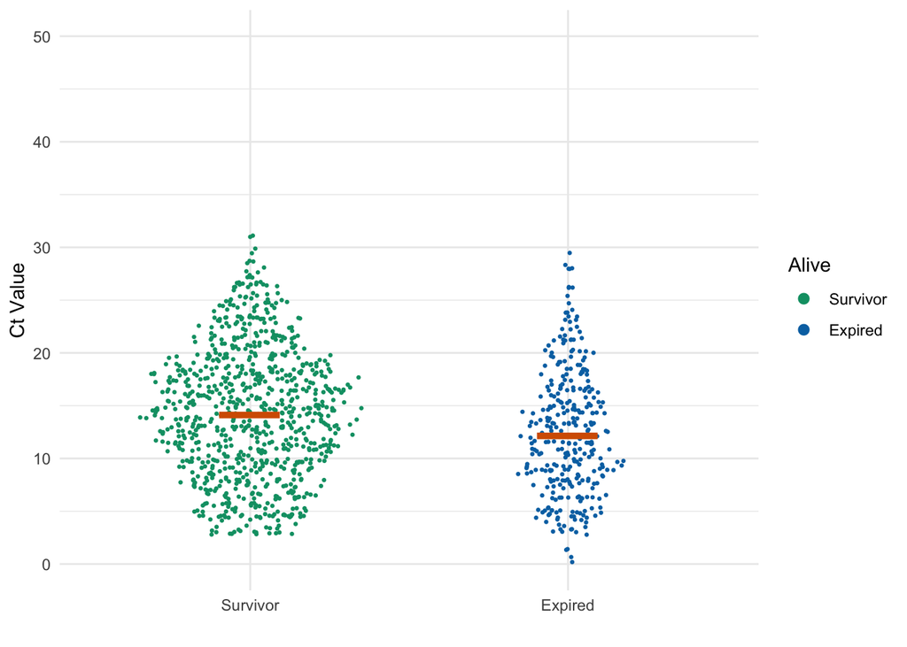

```r
# 95 percent confidence interval:
# 1.059992 2.669944
# sample estimates:
# difference in location
#              1.859981

fig_ct_method_abbott <- ggplot(abbott_dat_mort, aes(x=Alive, y=Ct, fill=Alive)) +
geom_dotplot(binaxis='y', stackdir='center', stackratio=.5, dotsize=.25, col=NA, position = position_jitterd(width = .05, height = 1, quad.points = 1, seed = 7)) +
  theme_minimal() +
  scale_fill_manual(values=colorBlindBlack8[c(4,6)]) +
  stat_summary(data = abbott_dat_mort, mapping = aes(x=as.numeric(as.factor((Alive))), y=Ct), fun.y= "median", geom="point", color=colorBlindBlack8[7], inherit.aes = FALSE, shape = 95, size=20) +
  xlab("")+
  ylab("Ct Value") +
  ylim(c(0,50))
fig_ct_method_abbott
```

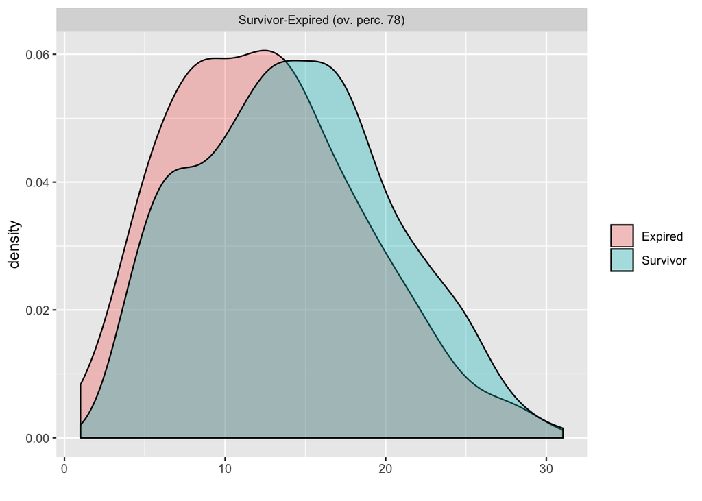

```r
#ggsave(plot = fig_ct_method_abbott, filename = "Fig1_abbott.pdf", width=4.5, height=3, useDingbats=FALSE)


# plot AUC overlap between survivor and expired
AUC_overlap_abbott <- list(Survivor=abbott_dat_mort$Ct[abbott_dat_mort$Alive=="Survivor"], Expired=abbott_dat_mort$Ct[abbott_dat_mort$Alive=="Expired"])
AUC_overlap_plot_abbott <- overlap(AUC_overlap_abbott, plot=TRUE, theme = theme_minimal)
```

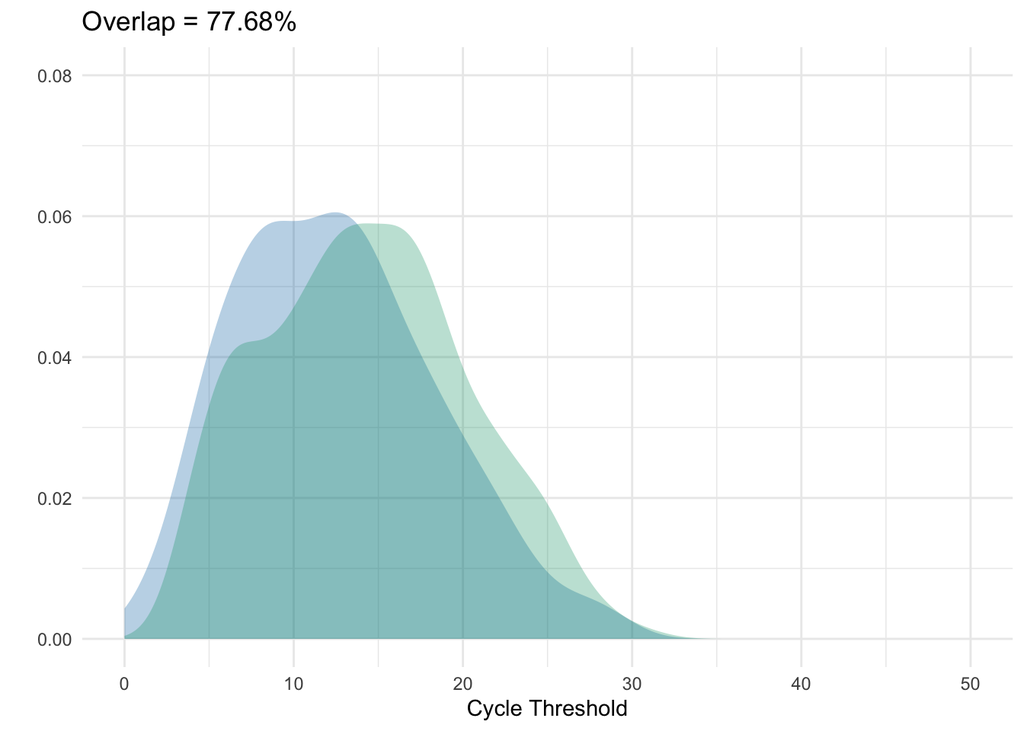

```r
fig_ct_overlap_abbott <- ggplot(AUC_overlap_plot_abbott$DD, aes(x,y1)) +
  geom_ribbon(aes(ymin=0,ymax=y2),alpha=.3,fill=colorBlindBlack8[c(6)])+
  geom_ribbon(aes(ymin=0,ymax=y1),alpha=.3,fill=colorBlindBlack8[c(4)])+
  xlab("Cycle Threshold")+
  xlim(c(0,50)) +
  ylab("") +
  ylim(c(0,0.08))+
  theme_minimal()+
  ggtitle(paste0("Overlap = ",round(AUC_overlap_plot_abbott$OV*100,2),"%"))
fig_ct_overlap_abbott
```

```r
#ggsave(plot = fig_ct_overlap_abbott, filename = "Fig1_overlap_abbott.pdf", width=2.5, height=2.5, useDingbats=FALSE)
```

2c) Obtaining the Youden Index for the Abbott machine

```r
rocfit_abbott <- pROC::roc(as.character(abbott_dat_mort$Alive), abbott_dat_mort$Ct)
pROC::auc(rocfit_abbott)
```

```
## Area under the curve: 0.5847
```

```r
youden_coord_abbott<- pROC::coords(rocfit_abbott, x = "b")
youden_coord_abbott
```

```
##   threshold specificity sensitivity
## 1     15.62   0.7191358   0.4226328
```

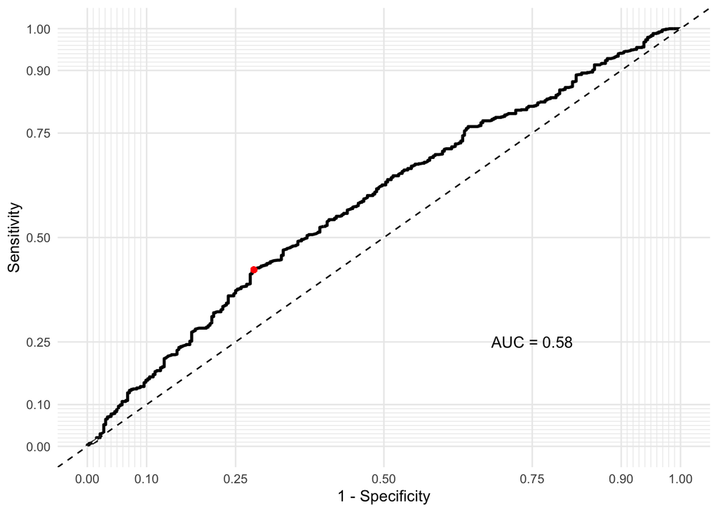

```r
rocplot_abbott<- ggplot(abbott_dat_mort, aes(m = Ct, d = Alive)) +
  geom_roc(n.cuts=0)
rocplot_abbott <- rocplot_abbott + style_roc(theme = theme_minimal, xlab = "1 - Specificity", ylab = "Sensitivity") +
  annotate("text", x = .75, y = .25,
           label = paste("AUC =", round(calc_auc(rocplot_abbott)$AUC, 2)))  +
  geom_point(aes(x=1-youden_coord_abbott$specificity, y=youden_coord_abbott$sensitivity), colour="red")+
  geom_abline(slope=1, intercept=0, lty="dashed")
  #ggtitle("abbott ROC")
rocplot_abbott
```

```r
#ggsave(plot = rocplot_abbott, filename = "Fig1_roc_abbott.pdf", width=2.5, height=2.5, useDingbats=FALSE)
```

3. Examine the variability of samples taken within 48 hours of each other. reading and curating data from pairs of Ct value from Abbott and Cephied

```r
pairs_dat <- fread("Data_used/within_48.csv", header = T)
pairs_dat <- as.data.frame(pairs_dat)
dim(pairs_dat) #93 9
```

```
## [1] 93  9
```

```r
# how many different machines
table(pairs_dat$Method)
```

```
##
##  Abbott Cephied Hologic
##      16      30      47
```

```r
#sanity check- duplicated specimen IDs?
any(duplicated(pairs_dat$Spec_name)) # FALSE
```

```
## [1] FALSE
```

```r
#parsing the date and time information
pairs_dat$collect_parse <- parse_date_time(pairs_dat$Collected, orders="m/d/y H:M p")

# sort based on MRN then time collected
pairs_dat <- pairs_dat[order(pairs_dat$mrn, pairs_dat$collect_parse),]

# how many patients have more than 2 samples? # two have 3, one has 5
table(table(pairs_dat$mrn))
```

```
##
##  2  3  5
## 41  2  1
```

```r
# split into list
split_pairs <- split(pairs_dat, pairs_dat$mrn)

pairs_df <- data.frame()
j<-1
for (i in 1:length(split_pairs)){
  if(nrow(split_pairs[[i]])<3){
    pairs_df[j,1] <- split_pairs[[i]]$mrn[1]
    pairs_df[j,2] <- diff(split_pairs[[i]]$Ct)
    pairs_df[j,3] <- as.numeric(difftime(split_pairs[[i]]$collect_parse[2],split_pairs[[i]]$collect_parse[1], units="hours"))
    pairs_df[j,4] <- split_pairs[[i]]$Age[1]
    pairs_df[j,5] <- split_pairs[[i]]$Sex[1]
    pairs_df[j,6] <- split_pairs[[i]]$Method[1]
    pairs_df[j,7] <- (split_pairs[[i]]$Method[1]==split_pairs[[i]]$Method[2])
    pairs_df[j,8] <- split_pairs[[i]]$Ct[1]
    pairs_df[j,9] <- split_pairs[[i]]$Ct[2]
    pairs_df[j,10] <- mean(split_pairs[[i]]$Ct)
    pairs_df[j,11] <- split_pairs[[i]]$collect_parse[1]
    j<- j+1
  }
  else {
    for (k in 2:nrow(split_pairs[[i]])){
      pairs_df[j,1] <- split_pairs[[i]]$mrn[1]
      pairs_df[j,2] <- split_pairs[[i]]$Ct[k] - split_pairs[[i]]$Ct[1]
      pairs_df[j,3] <- as.numeric(difftime(split_pairs[[i]]$collect_parse[k],split_pairs[[i]]$collect_parse[1], units="hours"))
      pairs_df[j,4] <- split_pairs[[i]]$Age[1]
      pairs_df[j,5] <- split_pairs[[i]]$Sex[1]
      pairs_df[j,6] <- split_pairs[[i]]$Method[k]
      pairs_df[j,7] <- (split_pairs[[i]]$Method[1]==split_pairs[[i]]$Method[k])
      pairs_df[j,8] <- split_pairs[[i]]$Ct[1]
      pairs_df[j,9] <- split_pairs[[i]]$Ct[k]
      pairs_df[j,10] <- (split_pairs[[i]]$Ct[1]+split_pairs[[i]]$Ct[k])/2
      pairs_df[j,11] <- split_pairs[[i]]$collect_parse[1]
      j<- j+1
    }
  }
}
colnames(pairs_df)<-c("MR", "CT_diff", "Time_diff", "Age", "Sex", "Method", "Method_match", "CT1", "CT2", "CT_mean", "first_collect_date")

#QC on Method matching
any(!pairs_df$Method_match)
```

```
## [1] FALSE
```

```r
# how many in first 24 hours
sum(length(pairs_df$CT_diff[pairs_df$Time_diff<24])) #19 in first 24 hours
```

```
## [1] 19
```

```r
sort(pairs_df$first_collect_date[pairs_df$Time_diff<48]) #7/40 are after May
```

```
##  [1] "2020-03-20 09:50:00 UTC" "2020-03-20 16:51:00 UTC"
##  [3] "2020-03-21 22:15:00 UTC" "2020-03-26 13:16:00 UTC"
##  [5] "2020-03-27 12:30:00 UTC" "2020-03-28 15:00:00 UTC"
##  [7] "2020-03-28 15:45:00 UTC" "2020-03-29 03:27:00 UTC"
##  [9] "2020-03-29 12:00:00 UTC" "2020-03-30 05:41:00 UTC"
## [11] "2020-03-30 20:24:00 UTC" "2020-03-31 10:09:00 UTC"
## [13] "2020-04-02 06:32:00 UTC" "2020-04-05 10:46:00 UTC"
## [15] "2020-04-06 18:28:00 UTC" "2020-04-07 05:20:00 UTC"
## [17] "2020-04-07 22:43:00 UTC" "2020-04-09 08:22:00 UTC"
## [19] "2020-04-13 16:37:00 UTC" "2020-04-17 16:05:00 UTC"
## [21] "2020-04-18 13:28:00 UTC" "2020-04-18 13:46:00 UTC"
## [23] "2020-05-08 21:50:00 UTC" "2020-05-13 10:36:00 UTC"
## [25] "2020-05-14 15:36:00 UTC" "2020-05-15 10:10:00 UTC"
## [27] "2020-05-15 11:12:00 UTC" "2020-05-15 15:35:00 UTC"
## [29] "2020-05-17 12:03:00 UTC" "2020-05-20 09:43:00 UTC"
## [31] "2020-05-20 11:37:00 UTC" "2020-05-20 16:58:00 UTC"
## [33] "2020-05-21 17:53:00 UTC" "2020-06-04 08:28:00 UTC"
## [35] "2020-06-17 14:12:00 UTC" "2020-07-05 09:58:00 UTC"
## [37] "2020-07-05 10:47:00 UTC" "2020-07-07 15:12:00 UTC"
## [39] "2020-07-07 15:33:00 UTC" "2020-07-28 13:21:00 UTC"
```

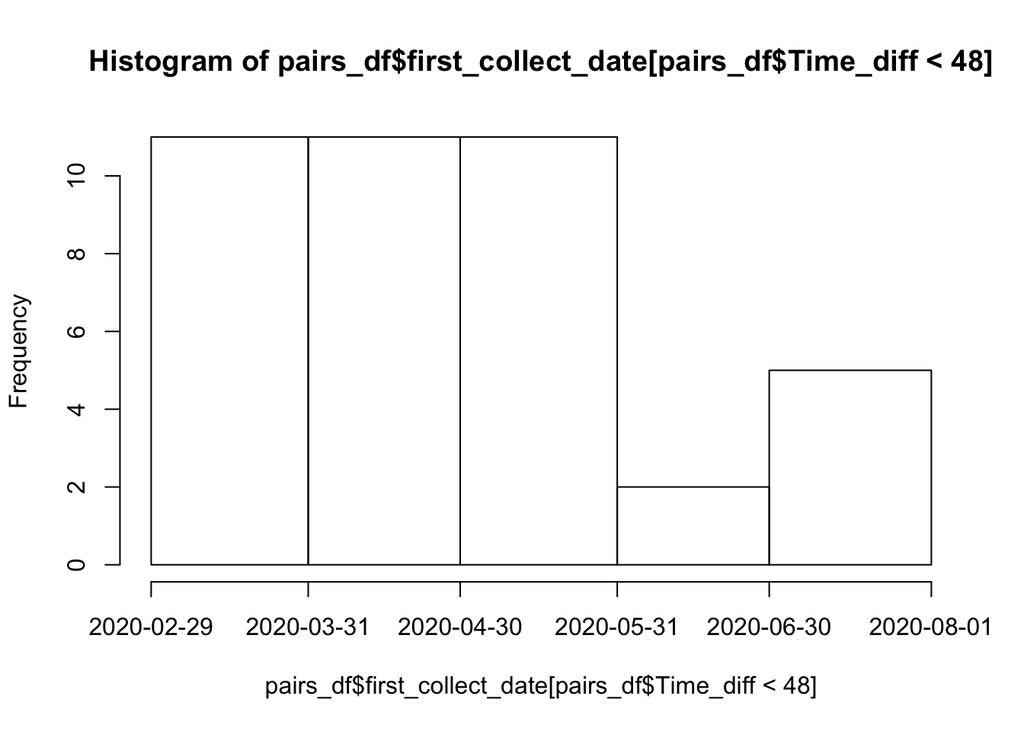

```r
hist(pairs_df$first_collect_date[pairs_df$Time_diff<48], "months", freq = TRUE)
```

```r
pairs_df$first_collect_date
```

```
##  [1] "2020-07-07 15:12:00 UTC" "2020-05-21 17:53:00 UTC"
##  [3] "2020-05-20 16:58:00 UTC" "2020-07-05 10:47:00 UTC"
##  [5] "2020-03-28 15:00:00 UTC" "2020-05-15 10:10:00 UTC"
##  [7] "2020-08-01 10:25:00 UTC" "2020-08-01 10:25:00 UTC"
##  [9] "2020-05-17 12:03:00 UTC" "2020-07-07 15:33:00 UTC"
## [11] "2020-05-08 21:50:00 UTC" "2020-03-30 20:24:00 UTC"
## [13] "2020-04-07 22:43:00 UTC" "2020-03-20 09:50:00 UTC"
## [15] "2020-05-13 10:36:00 UTC" "2020-04-05 10:46:00 UTC"
## [17] "2020-06-16 08:26:00 UTC" "2020-05-20 11:37:00 UTC"
## [19] "2020-04-07 05:20:00 UTC" "2020-04-06 18:28:00 UTC"
## [21] "2020-04-13 16:37:00 UTC" "2020-06-17 14:12:00 UTC"
## [23] "2020-05-29 13:54:00 UTC" "2020-03-27 12:30:00 UTC"
## [25] "2020-03-28 15:45:00 UTC" "2020-03-29 03:27:00 UTC"
## [27] "2020-07-28 13:21:00 UTC" "2020-05-15 11:12:00 UTC"
## [29] "2020-05-20 09:43:00 UTC" "2020-05-20 09:43:00 UTC"
## [31] "2020-05-20 09:43:00 UTC" "2020-05-20 09:43:00 UTC"
## [33] "2020-07-05 09:58:00 UTC" "2020-05-14 15:36:00 UTC"
## [35] "2020-03-30 05:41:00 UTC" "2020-05-15 15:35:00 UTC"
## [37] "2020-04-17 16:05:00 UTC" "2020-05-19 14:03:00 UTC"
## [39] "2020-05-19 14:03:00 UTC" "2020-04-18 13:28:00 UTC"
## [41] "2020-04-02 06:32:00 UTC" "2020-06-04 08:28:00 UTC"
## [43] "2020-03-26 13:16:00 UTC" "2020-03-20 16:51:00 UTC"
## [45] "2020-03-21 22:15:00 UTC" "2020-03-29 12:00:00 UTC"
## [47] "2020-03-31 10:09:00 UTC" "2020-04-18 13:46:00 UTC"
## [49] "2020-04-09 08:22:00 UTC"
```

plotting the pair with time on x, CT diff on y, fill by method

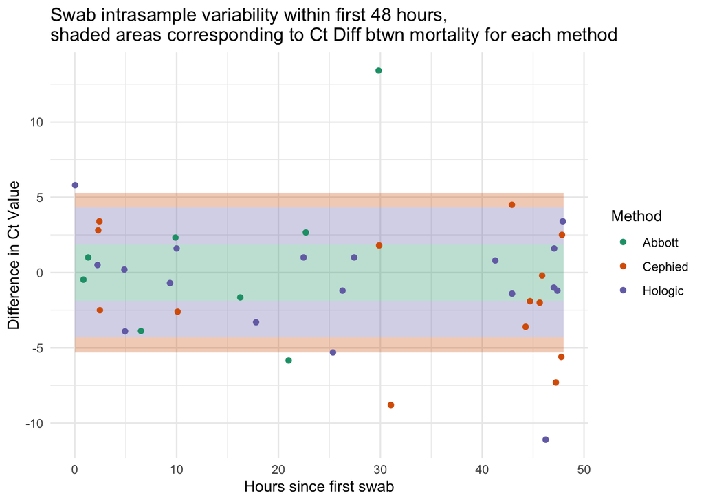

```r
# color scheme
dark_col <- brewer.pal(6,"Dark2")

# layering in CT differences for each machine
# Cephied 5.299954
# Hologic 4.299973
# Abbott  1.859981
ggplot(data=pairs_df, aes(x=Time_diff, y=CT_diff, col=Method))+
  annotate("rect", xmin = 0, xmax = 48, ymin = -1.859981, ymax = 1.859981,
        alpha = .3, fill=dark_col[1]) +
  annotate("rect", xmin = 0, xmax = 48, ymin = 1.859981, ymax = 4.299973,
        alpha = .3, fill=dark_col[3]) +
  annotate("rect", xmin = 0, xmax = 48, ymin = -1.859981, ymax = -4.299973,
        alpha = .3, fill=dark_col[3]) +
  annotate("rect", xmin = 0, xmax = 48, ymin = 4.299973, ymax = 5.299954,
        alpha = .3, fill=dark_col[2]) +
  annotate("rect", xmin = 0, xmax = 48, ymin = -4.299973, ymax = -5.299954,
        alpha = .3, fill=dark_col[2]) +
  geom_point()+
  theme_minimal() +
  scale_color_manual(values=dark_col)+
  xlab("Hours since first swab")+
  ylab("Difference in Ct Value")+
  xlim(c(0,48)) +
  ggtitle("Swab intrasample variability within first 48 hours,\nshaded areas corresponding to Ct Diff btwn mortality for each method")
```

4. Observe how many specimen pairs cross the Youden Index for their respective machine

```r
# grabbing only those pairs within 48 hours
pairs_df_48<- pairs_df[pairs_df$Time_diff<48,]
dim(pairs_df_48)
```

```
## [1] 40 11
```

```r
# Abbott
## number of pairs
sum(pairs_df_48$Method=="Abbott") #8
```

```
## [1] 8
```

```r
## number cross threshold
sum((pairs_df_48$CT1[pairs_df_48$Method=="Abbott"]<youden_coord_abbott$threshold &
       pairs_df_48$CT2[pairs_df_48$Method=="Abbott"]>youden_coord_abbott$threshold) |
      (pairs_df_48$CT1[pairs_df_48$Method=="Abbott"]>youden_coord_abbott$threshold &
         pairs_df_48$CT2[pairs_df_48$Method=="Abbott"]<youden_coord_abbott$threshold)) #3
```

```
## [1] 3
```

```r
idx_abbott_youden <- which((pairs_df_48$CT1[pairs_df_48$Method=="Abbott"]<youden_coord_abbott$threshold &
       pairs_df_48$CT2[pairs_df_48$Method=="Abbott"]>youden_coord_abbott$threshold) |
      (pairs_df_48$CT1[pairs_df_48$Method=="Abbott"]>youden_coord_abbott$threshold &
         pairs_df_48$CT2[pairs_df_48$Method=="Abbott"]<youden_coord_abbott$threshold)) #3

# Cepheid
## number of pairs
sum(pairs_df_48$Method=="Cephied") #14
```

```
## [1] 14
```

```r
## number cross threshold
sum((pairs_df_48$CT1[pairs_df_48$Method=="Cephied"]<youden_coord_cephied$threshold &
       pairs_df_48$CT2[pairs_df_48$Method=="Cephied"]>youden_coord_cephied$threshold) |
      (pairs_df_48$CT1[pairs_df_48$Method=="Cephied"]>youden_coord_cephied$threshold &
         pairs_df_48$CT2[pairs_df_48$Method=="Cephied"]<youden_coord_cephied$threshold)) #2
```

```
## [1] 2
```

```r
idx_Cephied_youden <- which((pairs_df_48$CT1[pairs_df_48$Method=="Cephied"]<youden_coord_cephied$threshold &
       pairs_df_48$CT2[pairs_df_48$Method=="Cephied"]>youden_coord_cephied$threshold) |
      (pairs_df_48$CT1[pairs_df_48$Method=="Cephied"]>youden_coord_cephied$threshold &
         pairs_df_48$CT2[pairs_df_48$Method=="Cephied"]<youden_coord_cephied$threshold)) #3
# Hologic
## number of pairs
sum(pairs_df_48$Method=="Hologic") #18
```

```
## [1] 18
```

```r
## number cross threshold
sum((pairs_df_48$CT1[pairs_df_48$Method=="Hologic"]<youden_coord_hologic$threshold &
       pairs_df_48$CT2[pairs_df_48$Method=="Hologic"]>youden_coord_hologic$threshold) |
      (pairs_df_48$CT1[pairs_df_48$Method=="Hologic"]>youden_coord_hologic$threshold &
         pairs_df_48$CT2[pairs_df_48$Method=="Hologic"]<youden_coord_hologic$threshold)) #3
```

```
## [1] 3
```

```r
idx_holo_youden <- which((pairs_df_48$CT1[pairs_df_48$Method=="Hologic"]<youden_coord_hologic$threshold &
       pairs_df_48$CT2[pairs_df_48$Method=="Hologic"]>youden_coord_hologic$threshold) |
      (pairs_df_48$CT1[pairs_df_48$Method=="Hologic"]>youden_coord_hologic$threshold &
         pairs_df_48$CT2[pairs_df_48$Method=="Hologic"]<youden_coord_hologic$threshold)) #3



pairs_df_48$CT1[pairs_df_48$Method=="Hologic"][idx_holo_youden]
```

```
## [1] 26.9 26.6 27.3
```

```r
## highlighting the pairs which crossed the Youden index
pairs_df_48$`Crossed Youden` <- "No"
pairs_df_48$`Crossed Youden`[pairs_df_48$Method=="Abbott"][idx_abbott_youden] <- "Yes"
pairs_df_48$`Crossed Youden`[pairs_df_48$Method=="Cephied"][idx_Cephied_youden] <- "Yes"
pairs_df_48$`Crossed Youden`[pairs_df_48$Method=="Hologic"][idx_holo_youden] <- "Yes"

#What is the mortality status of Crossed Youden samples?
crossed_pairs <- pairs_df_48[pairs_df_48$`Crossed Youden`=="Yes",]
crossed_pairs$direction <- ifelse(crossed_pairs$CT_diff>0, "up", "down")
idx_crossed_youden <- which(mort_dat$MRN %in% pairs_df_48[pairs_df_48$`Crossed Youden`=="Yes",1])
mort_dat[idx_crossed_youden,]
```

```
##       Specimen ID     MRN        Patient Name Patient Age Gender    Alive
## 608  MMI097200836 3067703     Almonte, Miguel     75 y.o.      M Survivor
## 635  MMI097200971 3067703     Almonte, Miguel     75 y.o.      M Survivor
## 684  MMI098200160 3055336     Santos, Ricardo    Deceased      M  Expired
## 741  MMI099200730 3055336     Santos, Ricardo    Deceased      M  Expired
## 1989 MMI134200528 5738314     Delacruz, Roque     82 y.o.      M Survivor
## 2044 MMI136200320 5738314     Delacruz, Roque     82 y.o.      M Survivor
## 2545 MVL076200740 2440655     Mitchell, Bobby    Deceased      M  Expired
## 2729 MVL080200299 2440655     Mitchell, Bobby    Deceased      M  Expired
## 2730 MVL080200301 2440655     Mitchell, Bobby    Deceased      M  Expired
## 2807 MVL081200106 6642876        Marin, Oscar     59 y.o.      M Survivor
## 3717 MVL087200059 6642876        Marin, Oscar     59 y.o.      M Survivor
## 3996 MVL088200130 6642876        Marin, Oscar     59 y.o.      M Survivor
## 4745 MVL091200404 6647511 Aguilar Mejia, Irma     48 y.o.      F Survivor
## 4848 MVL091200613 6647511 Aguilar Mejia, Irma     48 y.o.      F Survivor
## 5885 MVL096200132 2846415   Brewster, Corey D     41 y.o.      M Survivor
## 5917 MVL096200199 2846415   Brewster, Corey D     41 y.o.      M Survivor
## 6330 MVL099200007 2438630     Heckstall, Ruth     92 y.o.      F Survivor
## 6355 MVL099200127 2438630     Heckstall, Ruth     92 y.o.      F Survivor
## 7540 MVL141200255 5738314     Delacruz, Roque     82 y.o.      M Survivor
## 7583 MVL143200220 5738314     Delacruz, Roque     82 y.o.      M Survivor
## 7639 MVL147200668 5738314     Delacruz, Roque     82 y.o.      M Survivor
## 7677 MVL149200397 5738314     Delacruz, Roque     82 y.o.      M Survivor
## 7714 MVL153200772 5738314     Delacruz, Roque     82 y.o.      M Survivor
## 7752 MVL156200392 5738314     Delacruz, Roque     82 y.o.      M Survivor
## 9219 WMC127200080 5738314     Delacruz, Roque     82 y.o.      M Survivor
## 9382 WMC139200049 5738314     Delacruz, Roque     82 y.o.      M Survivor
```

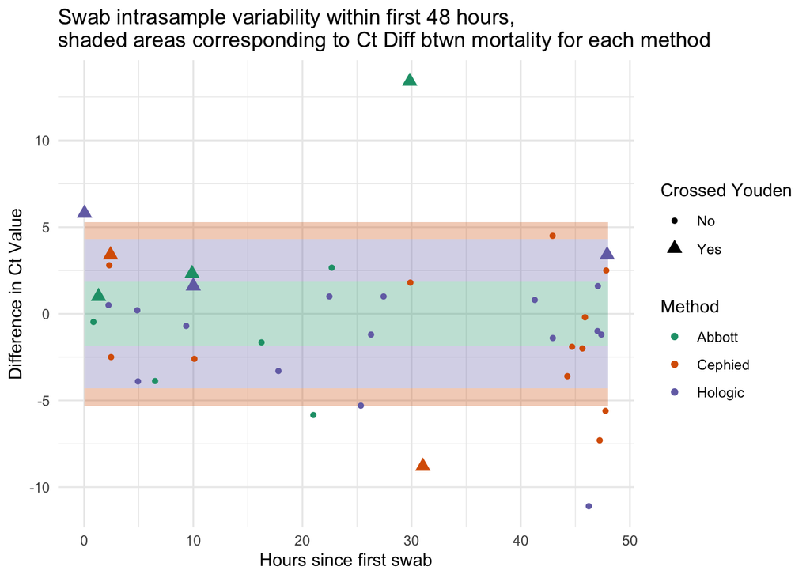

```r
# layering in CT differences for each machine
# Cephied 5.299954
# Hologic 4.299973
# Abbott  1.859981
Cross_youden_plot <- ggplot(data=pairs_df_48, aes(x=Time_diff, y=CT_diff, col=Method, size=`Crossed Youden`, shape=`Crossed Youden`))+
  annotate("rect", xmin = 0, xmax = 48, ymin = -1.859981, ymax = 1.859981,
        alpha = .3, fill=dark_col[1]) +
  annotate("rect", xmin = 0, xmax = 48, ymin = 1.859981, ymax = 4.299973,
        alpha = .3, fill=dark_col[3]) +
  annotate("rect", xmin = 0, xmax = 48, ymin = -1.859981, ymax = -4.299973,
        alpha = .3, fill=dark_col[3]) +
  annotate("rect", xmin = 0, xmax = 48, ymin = 4.299973, ymax = 5.299954,
        alpha = .3, fill=dark_col[2]) +
  annotate("rect", xmin = 0, xmax = 48, ymin = -4.299973, ymax = -5.299954,
        alpha = .3, fill=dark_col[2]) +
  geom_point()+
  theme_minimal() +
  scale_size_discrete(range = c(1.5, 3))+
  scale_color_manual(values=dark_col)+
  xlab("Hours since first swab")+
  ylab("Difference in Ct Value")+
  xlim(c(0,48)) +
  ggtitle("Swab intrasample variability within first 48 hours,\nshaded areas corresponding to Ct Diff btwn mortality for each method")
Cross_youden_plot
```

```r
#ggsave(plot = Cross_youden_plot, filename = "Fig2_youden_cross.pdf", width=6.5, height=4, useDingbats=FALSE)
```

Out of the 40 pairs, 8 crossed the youden index point for predicting mortality (20%). Lending evidence to being cautionary when using Ct value to predict mortality.